# Japanese & Korean politeness: Perception

## Z-scoring Japanese and creating marginal models for plotting:

Z-score all relevant variables:

```r
jprod_z <- mutate(jprod,
                  f0mnhz = (f0mnhz - mean(f0mnhz, na.rm = T)) / sd(f0mnhz, na.rm = T),
                  f0mdhz = (f0mdhz - mean(f0mdhz, na.rm = T)) / sd(f0mdhz, na.rm = T),
                  f0sdhz = (f0sdhz - mean(f0sdhz, na.rm = T)) / sd(f0sdhz, na.rm = T),
                  f0rghz = (f0rghz - mean(f0rghz, na.rm = T)) / sd(f0rghz, na.rm = T),
                  inmn = (inmn - mean(inmn, na.rm = T)) / sd(inmn, na.rm = T),
                  inmd = (inmd - mean(inmd, na.rm = T)) / sd(inmd, na.rm = T),
                  insd = (insd -mean(insd, na.rm = T)) / sd(insd, na.rm = T),
                  inrange = (inrange - mean(inrange, na.rm = T)) / sd(inrange, na.rm = T),
                  jitloc = (jitloc - mean(jitloc, na.rm = T)) / sd(jitloc, na.rm = T),
                  shimloc = (shimloc - mean(shimloc, na.rm = T)) / sd(shimloc, na.rm = T),
                  h1mh2mn = (h1mh2mn - mean(h1mh2mn, na.rm = T)) / sd(h1mh2mn, na.rm = T),
                  mnHNR = (mnHNR - mean(mnHNR, na.rm = T)) / sd(mnHNR, na.rm = T),
                  dur = (dur - mean(dur, na.rm = T)) / sd(dur, na.rm = T),
                  rate = (rate - mean(rate, na.rm = T)) / sd(rate, na.rm = T))
```

Get subsets of DCT (ppt) and reading task (epr):

```r
jprod_ppt <- filter(jprod_z, task == 'ppt')
jprod_epr <- filter(jprod_z, task == 'epr')
```

Create marginal models (no interaction) for plotting:

```r
# F0:

j_ppt_f0 <- mixed(f0mdhz ~ condition2_c + gender_c +
                    (1 + condition2_c|speaker) +
                    (1 + condition2_c|item),
                  data = jprod_ppt,
                  method = 'LRT')
```

```
## Numerical variables NOT centered on 0: condition2_c, gender_c
## If in interactions, interpretation of lower order (e.g., main) effects difficult.
```

```
## REML argument to lmer() set to FALSE for method = 'PB' or 'LRT'
```

```
## Fitting 3 (g)lmer() models:
## [...]
```

```r
j_epr_f0 <- mixed(f0mdhz ~ condition2_c + gender_c +
                    (1 + condition2_c|speaker) +
                    (1 + condition2_c|item),
                  data = jprod_epr,
                  method = 'LRT')
```

```
## Numerical variables NOT centered on 0: gender_c
## If in interactions, interpretation of lower order (e.g., main) effects difficult.
## REML argument to lmer() set to FALSE for method = 'PB' or 'LRT'
```

```
## Fitting 3 (g)lmer() models:
## [...]
```

```r
# F0 sd:

j_ppt_f0sd <- mixed(f0sdhz ~ condition2_c + gender_c +
                    (1 + condition2_c|speaker) +
                    (1 + condition2_c|item),
                  data = jprod_ppt,
                  method = 'LRT')
```

```
## Numerical variables NOT centered on 0: condition2_c, gender_c
## If in interactions, interpretation of lower order (e.g., main) effects difficult.
## REML argument to lmer() set to FALSE for method = 'PB' or 'LRT'
```

```
## Fitting 3 (g)lmer() models:
## [...]
```

```r
j_epr_f0sd <- mixed(f0sdhz ~ condition2_c + gender_c +
                    (1 + condition2_c|speaker) +
                    (1 + condition2_c|item),
                  data = jprod_epr,
                  method = 'LRT')
```

```
## Numerical variables NOT centered on 0: gender_c
## If in interactions, interpretation of lower order (e.g., main) effects difficult.
## REML argument to lmer() set to FALSE for method = 'PB' or 'LRT'
```

```
## Fitting 3 (g)lmer() models:
## [...]
```

```r
# Intensity:

j_ppt_int <- mixed(inmd ~ condition2_c + gender_c +
                    (1 + condition2_c|speaker) +
                    (1 + condition2_c|item),
                  data = jprod_ppt,
                  method = 'LRT')
```

```
## Numerical variables NOT centered on 0: condition2_c, gender_c
## If in interactions, interpretation of lower order (e.g., main) effects difficult.
## REML argument to lmer() set to FALSE for method = 'PB' or 'LRT'
```

```
## Fitting 3 (g)lmer() models:
## [...]
```

```r
j_epr_int <- mixed(inmd ~ condition2_c + gender_c +
                    (1 + condition2_c|speaker) +
                    (1 + condition2_c|item),
                  data = jprod_epr,
                  method = 'LRT')
```

```
## Numerical variables NOT centered on 0: gender_c
## If in interactions, interpretation of lower order (e.g., main) effects difficult.
## REML argument to lmer() set to FALSE for method = 'PB' or 'LRT'
```

```
## Fitting 3 (g)lmer() models:
## [...]
```

```r
# Intensity variability (SD):

j_ppt_intsd <- mixed(insd ~ condition2_c + gender_c +
                    (1 + condition2_c|speaker) +
                    (1 + condition2_c|item),
                  data = jprod_ppt,
                  method = 'LRT')
```

```
## Numerical variables NOT centered on 0: condition2_c, gender_c
## If in interactions, interpretation of lower order (e.g., main) effects difficult.
## REML argument to lmer() set to FALSE for method = 'PB' or 'LRT'
```

```
## Fitting 3 (g)lmer() models:
## [...]
```

```r
j_epr_intsd <- mixed(insd ~ condition2_c + gender_c +
                    (1 + condition2_c|speaker) +
                    (1 + condition2_c|item),
                  data = jprod_epr,
                  method = 'LRT')
```

```
## Numerical variables NOT centered on 0: gender_c
## If in interactions, interpretation of lower order (e.g., main) effects difficult.
## REML argument to lmer() set to FALSE for method = 'PB' or 'LRT'
```

```
## Fitting 3 (g)lmer() models:
## [...]
```

```r
# Shimmer:

j_ppt_shim <- mixed(shimloc ~ condition2_c + gender_c +
                    (1 + condition2_c|speaker) +
                    (1 + condition2_c|item),
                  data = jprod_ppt,
                  method = 'LRT')
```

```
## Numerical variables NOT centered on 0: condition2_c, gender_c
## If in interactions, interpretation of lower order (e.g., main) effects difficult.
## REML argument to lmer() set to FALSE for method = 'PB' or 'LRT'
```

```
## Fitting 3 (g)lmer() models:
## [...]
```

```r
j_epr_shim <- mixed(shimloc ~ condition2_c + gender_c +
                    (1 + condition2_c|speaker) +
                    (1 + condition2_c|item),
                  data = jprod_epr,
                  method = 'LRT')
```

```
## Numerical variables NOT centered on 0: gender_c
## If in interactions, interpretation of lower order (e.g., main) effects difficult.
## REML argument to lmer() set to FALSE for method = 'PB' or 'LRT'
```

```
## Fitting 3 (g)lmer() models:
## [...]
```

```r
# Jitter:

j_ppt_jit <- mixed(jitloc ~ condition2_c + gender_c +
                    (1 + condition2_c|speaker) +
                    (1 + condition2_c|item),
                  data = jprod_ppt,
                  method = 'LRT')
```

```
## Numerical variables NOT centered on 0: condition2_c, gender_c
## If in interactions, interpretation of lower order (e.g., main) effects difficult.
## REML argument to lmer() set to FALSE for method = 'PB' or 'LRT'
```

```
## Fitting 3 (g)lmer() models:
## [...]
```

```r
j_epr_jit <- mixed(jitloc ~ condition2_c + gender_c +
                    (1 + condition2_c|speaker) +
                    (1 + condition2_c|item),
                  data = jprod_epr,
                  method = 'LRT')
```

```
## Numerical variables NOT centered on 0: gender_c
## If in interactions, interpretation of lower order (e.g., main) effects difficult.
## REML argument to lmer() set to FALSE for method = 'PB' or 'LRT'
```

```
## Fitting 3 (g)lmer() models:
## [...]
```

```r
# H1-H2:

j_ppt_h1h2 <- mixed(h1mh2mn ~ condition2_c + gender_c +
                    (1 + condition2_c|speaker) +
                    (1 + condition2_c|item),
                  data = jprod_ppt,
                  method = 'LRT')
```

```
## Numerical variables NOT centered on 0: condition2_c, gender_c
## If in interactions, interpretation of lower order (e.g., main) effects difficult.
## REML argument to lmer() set to FALSE for method = 'PB' or 'LRT'
```

```
## Fitting 3 (g)lmer() models:
## [...]
```

```r
j_epr_h1h2 <- mixed(h1mh2mn ~ condition2_c + gender_c +
                    (1 + condition2_c|speaker) +
                    (1 + condition2_c|item),
                  data = jprod_epr,
                  method = 'LRT')
```

```
## Numerical variables NOT centered on 0: gender_c
## If in interactions, interpretation of lower order (e.g., main) effects difficult.
## REML argument to lmer() set to FALSE for method = 'PB' or 'LRT'
```

```
## Fitting 3 (g)lmer() models:
## [...]
```

```r
# HNR:

j_ppt_HNR <- mixed(mnHNR ~ condition2_c + gender_c +
                    (1 + condition2_c|speaker) +
                    (1 + condition2_c|item),
                  data = jprod_ppt,
                  method = 'LRT')
```

```
## Numerical variables NOT centered on 0: condition2_c, gender_c
## If in interactions, interpretation of lower order (e.g., main) effects difficult.
## REML argument to lmer() set to FALSE for method = 'PB' or 'LRT'
```

```
## Fitting 3 (g)lmer() models:
## [...]
```

```r
j_epr_HNR <- mixed(mnHNR ~ condition2_c + gender_c +
                    (1 + condition2_c|speaker) +
                    (1 + condition2_c|item),
                  data = jprod_epr,
                  method = 'LRT')
```

```
## Numerical variables NOT centered on 0: gender_c
## If in interactions, interpretation of lower order (e.g., main) effects difficult.
## REML argument to lmer() set to FALSE for method = 'PB' or 'LRT'
```

```
## Fitting 3 (g)lmer() models:
## [...]
```

```r
# Rate:

j_ppt_rate <- mixed(rate ~ condition2_c + gender_c +
                    (1 + condition2_c|speaker) +
                    (1 + condition2_c|item),
                  data = jprod_ppt,
                  method = 'LRT')
```

```
## Numerical variables NOT centered on 0: condition2_c, gender_c
## If in interactions, interpretation of lower order (e.g., main) effects difficult.
## REML argument to lmer() set to FALSE for method = 'PB' or 'LRT'
```

```
## Fitting 3 (g)lmer() models:
## [...]
```

```r
j_epr_rate <- mixed(rate ~ condition2_c + gender_c +
                    (1 + condition2_c|speaker) +
                    (1 + condition2_c|item),
                  data = jprod_epr,
                  method = 'LRT')
```

```
## Numerical variables NOT centered on 0: gender_c
## If in interactions, interpretation of lower order (e.g., main) effects difficult.
## REML argument to lmer() set to FALSE for method = 'PB' or 'LRT'
```

```
## Fitting 3 (g)lmer() models:
## [...]
```

## Preprocess Korean data

Load in Korean data:

```r
wg2012 <- read_csv('../data/KRNpolitenessWinterGrawunder2012.csv')
brown2014 <- read_csv('../data/KRNpolitenessProduction_2014.csv')
```

Rename the Korean data for matching acoustic variable names:

```r
## Process the Korean data:

wg2012 <- wg2012 %>%
  select(language, gender, speaker, task,
         scenario, attitude, dur, rate, f0mnhz,
         f0mdhz, f0sdhz, inmn, inmd, insd, jitloc,
         shimloc, h1mh2mn, mnHNR) %>%
  rename(condition = attitude, item = scenario,
         f0mn = f0mnhz, f0md = f0mdhz, f0sd = f0sdhz)

brown2014 <- brown2014 %>%
  select(language, gender, task,
           scenario, speaker, condition2,
         dur, rate, f0mnhz, f0mdhz, f0sdhz,
         inmn, inmd, insd, jitloc, shimloc,
         h1mh2mn, mnHNR) %>%
  rename(condition = condition2, item = scenario,
         f0mn = f0mnhz, f0md = f0mdhz, f0sd = f0sdhz)
```

Extract only powerpoint task of Winter & Grawunder (2012) (exclude note task, and newspaper):

```r
wg2012 <- filter(wg2012, task == 'dct')
```

Log-transform the duration measure for both datasets:

```r
wg2012 <- mutate(wg2012,
                duroriginal = dur,
                dur = log10(dur))
brown2014 <- mutate(brown2014,
                duroriginal = dur,
                dur = log10(dur))
```

Z-score all relevant acoustic variables in both tables:

```r
## Z-score everything, Winter & Grawunder (2012):

wg2012_z <- mutate(wg2012,
                   dur = (dur - mean(dur, na.rm = T)) / sd(dur, na.rm = T),
                   rate = (rate - mean(rate, na.rm = T)) / sd(rate, na.rm = T),
                   inmn = (inmn - mean(inmn, na.rm = T)) / sd(inmn, na.rm = T),
                   inmd = (inmd - mean(inmd, na.rm = T)) / sd(inmd, na.rm = T),
                   insd = (insd - mean(insd, na.rm = T)) / sd(insd, na.rm = T),
                   f0mn = (f0mn - mean(f0mn, na.rm = T)) / sd(f0mn, na.rm = T),
                   f0md = (f0md - mean(f0md, na.rm = T)) / sd(f0md, na.rm = T),
                   f0sd = (f0sd - mean(f0sd, na.rm = T)) / sd(f0sd, na.rm = T),
                   jitloc = (jitloc - mean(jitloc, na.rm = T)) / sd(jitloc, na.rm = T),
                   shimloc = (shimloc - mean(shimloc, na.rm = T)) / sd(shimloc, na.rm = T),
                   h1mh2mn = (h1mh2mn - mean(h1mh2mn, na.rm = T)) / sd(h1mh2mn, na.rm = T),
                   mnHNR = (mnHNR - mean(mnHNR, na.rm = T)) / sd(mnHNR, na.rm = T))

## Z-score everything, Brown et al.(2014):

brown2014_z <- mutate(brown2014,
                      dur = (dur - mean(dur, na.rm = T)) / sd(dur, na.rm = T),
                      rate = (rate - mean(rate, na.rm = T)) / sd(rate, na.rm = T),
                      inmn = (inmn - mean(inmn, na.rm = T)) / sd(inmn, na.rm = T),
                      inmd = (inmd - mean(inmd, na.rm = T)) / sd(inmd, na.rm = T),
                      insd = (insd - mean(insd, na.rm = T)) / sd(insd, na.rm = T),
                      f0mn = (f0mn - mean(f0mn, na.rm = T)) / sd(f0mn, na.rm = T),
                      f0md = (f0md - mean(f0md, na.rm = T)) / sd(f0md, na.rm = T),
                      f0sd = (f0sd - mean(f0sd, na.rm = T)) / sd(f0sd, na.rm = T),
                      jitloc = (jitloc - mean(jitloc, na.rm = T)) / sd(jitloc, na.rm = T),
                      shimloc = (shimloc - mean(shimloc, na.rm = T)) / sd(shimloc, na.rm = T),
                      h1mh2mn = (h1mh2mn - mean(h1mh2mn, na.rm = T)) / sd(h1mh2mn, na.rm = T),
                      mnHNR = (mnHNR - mean(mnHNR, na.rm = T)) / sd(mnHNR, na.rm = T))
```

To keep everything consistent (even though there are no interactions), make things into deviation coded factors:

```r
brown2014_z <- mutate(brown2014_z,
                      condition2_c = ifelse(condition == 'polite', 0.5, -0.5),
                      gender_c = ifelse(gender == 'M', 0.5, -0.5))
wg2012_z <- mutate(wg2012_z,
                   condition2_c = ifelse(condition == 'pol', 0.5, -0.5),
                   gender_c = ifelse(gender == 'M', 0.5, -0.5))
```

## Create marginal models for plotting, Korean:

```r
## Pitch (median):

k_ppt_f0 <- mixed(f0md ~ condition2_c + gender_c +
                    (1 + condition2_c|speaker) +
                    (1 + condition2_c|item),
                  data = wg2012_z, method = 'LRT')
```

```
## Numerical variables NOT centered on 0: gender_c
## If in interactions, interpretation of lower order (e.g., main) effects difficult.
```

```
## REML argument to lmer() set to FALSE for method = 'PB' or 'LRT'
```

```
## Fitting 3 (g)lmer() models:
## [...]
```

```r
k_epr_f0 <- mixed(f0md ~ condition2_c + gender_c +
                    (1 + condition2_c|speaker) +
                    (1 + condition2_c|item),
                  data = brown2014_z, method = 'LRT')
```

```
## REML argument to lmer() set to FALSE for method = 'PB' or 'LRT'
```

```
## Fitting 3 (g)lmer() models:
## [...]
```

```r
## Pitch variability (sd):

k_ppt_f0sd <- mixed(f0sd ~ condition2_c + gender_c +
                      (1 + condition2_c|speaker) +
                      (1 + condition2_c|item),
                    data = wg2012_z, method = 'LRT')
```

```
## Numerical variables NOT centered on 0: gender_c
## If in interactions, interpretation of lower order (e.g., main) effects difficult.
## REML argument to lmer() set to FALSE for method = 'PB' or 'LRT'
```

```
## Fitting 3 (g)lmer() models:
## [...]
```

```r
k_epr_f0sd <- mixed(f0sd ~ condition2_c + gender_c +
                      (1 + condition2_c|speaker) +
                      (1 + condition2_c|item),
                    data = brown2014_z, method = 'LRT')
```

```
## REML argument to lmer() set to FALSE for method = 'PB' or 'LRT'
```

```
## Fitting 3 (g)lmer() models:
## [...]
```

```r
## Intensity (median):

k_ppt_int <- mixed(inmd ~ condition2_c + gender_c +
                     (1 + condition2_c|speaker) +
                     (1 + condition2_c|item),
                   data = wg2012_z, method = 'LRT')
```

```
## Numerical variables NOT centered on 0: gender_c
## If in interactions, interpretation of lower order (e.g., main) effects difficult.
## REML argument to lmer() set to FALSE for method = 'PB' or 'LRT'
```

```
## Fitting 3 (g)lmer() models:
## [...]
```

```r
k_epr_int <- mixed(inmd ~ condition2_c + gender_c +
                     (1 + condition2_c|speaker) +
                     (1 + condition2_c|item),
                   data = brown2014_z, method = 'LRT')
```

```
## REML argument to lmer() set to FALSE for method = 'PB' or 'LRT'
```

```
## Fitting 3 (g)lmer() models:
## [...]
```

```r
## Intensity variability (sd):

k_ppt_intsd <- mixed(insd ~ condition2_c + gender_c +
                       (1 + condition2_c|speaker) +
                       (1 + condition2_c|item),
                     data = wg2012_z, method = 'LRT')
```

```
## Numerical variables NOT centered on 0: gender_c
## If in interactions, interpretation of lower order (e.g., main) effects difficult.
## REML argument to lmer() set to FALSE for method = 'PB' or 'LRT'
```

```
## Fitting 3 (g)lmer() models:
## [...]
```

```r
k_epr_intsd <- mixed(insd ~ condition2_c + gender_c +
                       (1 + condition2_c|speaker) +
                       (1 + condition2_c|item),
                     data = brown2014_z, method = 'LRT')
```

```
## REML argument to lmer() set to FALSE for method = 'PB' or 'LRT'
```

```
## Fitting 3 (g)lmer() models:
## [...]
```

```r
## Shimmer:

k_ppt_shim <- mixed(shimloc ~ condition2_c + gender_c +
                      (1 + condition2_c|speaker) +
                      (1 + condition2_c|item),
                    data = wg2012_z, method = 'LRT')
```

```
## Numerical variables NOT centered on 0: gender_c
## If in interactions, interpretation of lower order (e.g., main) effects difficult.
## REML argument to lmer() set to FALSE for method = 'PB' or 'LRT'
```

```
## Fitting 3 (g)lmer() models:
## [...]
```

```r
k_epr_shim <- mixed(shimloc ~ condition2_c + gender_c +
                      (1 + condition2_c|speaker) +
                      (1 + condition2_c|item),
                    data = brown2014_z, method = 'LRT')
```

```
## REML argument to lmer() set to FALSE for method = 'PB' or 'LRT'
```

```
## Fitting 3 (g)lmer() models:
## [...]
```

```r
## Jitter:

k_ppt_jit <- mixed(jitloc ~ condition2_c + gender_c +
                      (1 + condition2_c|speaker) +
                      (1 + condition2_c|item),
                    data = wg2012_z, method = 'LRT')
```

```
## Numerical variables NOT centered on 0: gender_c
## If in interactions, interpretation of lower order (e.g., main) effects difficult.
## REML argument to lmer() set to FALSE for method = 'PB' or 'LRT'
```

```
## Fitting 3 (g)lmer() models:
## [...]
```

```r
k_epr_jit <- mixed(jitloc ~ condition2_c + gender_c +
                      (1 + condition2_c|speaker) +
                      (1 + condition2_c|item),
                    data = brown2014_z, method = 'LRT')
```

```
## REML argument to lmer() set to FALSE for method = 'PB' or 'LRT'
```

```
## Fitting 3 (g)lmer() models:
## [...]
```

```r
## H1-H2:

k_ppt_h1h2 <- mixed(h1mh2mn ~ condition2_c + gender_c +
                      (1 + condition2_c|speaker) +
                      (1 + condition2_c|item),
                    data = wg2012_z, method = 'LRT')
```

```
## Numerical variables NOT centered on 0: gender_c
## If in interactions, interpretation of lower order (e.g., main) effects difficult.
## REML argument to lmer() set to FALSE for method = 'PB' or 'LRT'
```

```
## Fitting 3 (g)lmer() models:
## [.
```

```
## ..]
```

```r
k_epr_h1h2 <- mixed(h1mh2mn ~ condition2_c + gender_c +
                      (1 + condition2_c|speaker) +
                      (1 + condition2_c|item),
                    data = brown2014_z, method = 'LRT')
```

```
## REML argument to lmer() set to FALSE for method = 'PB' or 'LRT'
```

```
## Fitting 3 (g)lmer() models:
## [...]
```

```r
## HNR:

k_ppt_HNR <- mixed(mnHNR ~ condition2_c + gender_c +
                      (1 + condition2_c|speaker) +
                      (1 + condition2_c|item),
                    data = wg2012_z, method = 'LRT')
```

```
## Numerical variables NOT centered on 0: gender_c
## If in interactions, interpretation of lower order (e.g., main) effects difficult.
## REML argument to lmer() set to FALSE for method = 'PB' or 'LRT'
```

```
## Fitting 3 (g)lmer() models:
## [...]
```

```r
k_epr_HNR <- mixed(mnHNR ~ condition2_c + gender_c +
                      (1 + condition2_c|speaker) +
                      (1 + condition2_c|item),
                    data = brown2014_z, method = 'LRT')
```

```
## REML argument to lmer() set to FALSE for method = 'PB' or 'LRT'
```

```
## Fitting 3 (g)lmer() models:
## [...]
```

```r
## Rate:

k_ppt_rate <- mixed(rate ~ condition2_c + gender_c +
                      (1 + condition2_c|speaker) +
                      (1 + condition2_c|item),
                    data = wg2012_z, method = 'LRT')
```

```
## Numerical variables NOT centered on 0: gender_c
## If in interactions, interpretation of lower order (e.g., main) effects difficult.
## REML argument to lmer() set to FALSE for method = 'PB' or 'LRT'
```

```
## Fitting 3 (g)lmer() models:
## [...]
```

```r
k_epr_rate <- mixed(rate ~ condition2_c + gender_c +
                      (1 + condition2_c|speaker) +
                      (1 + condition2_c|item),
                    data = brown2014_z, method = 'LRT')
```

```
## REML argument to lmer() set to FALSE for method = 'PB' or 'LRT'
```

```
## Fitting 3 (g)lmer() models:
## [...]
```

## Plot comparing Korean and Japanese across tasks and acoustic variables

First, let’s create a vector of names for the models.

```r
mypreds <- c('f0', 'f0sd', 'int', 'intsd', 'jit',
             'shim', 'h1h2', 'HNR', 'rate')
```

Set plotting parameters. x_fac determines the distance between the languages on the x-axis.

```r
x_fac <- 0.2
```

The following is the actual plot. quartz() only works on Macs.

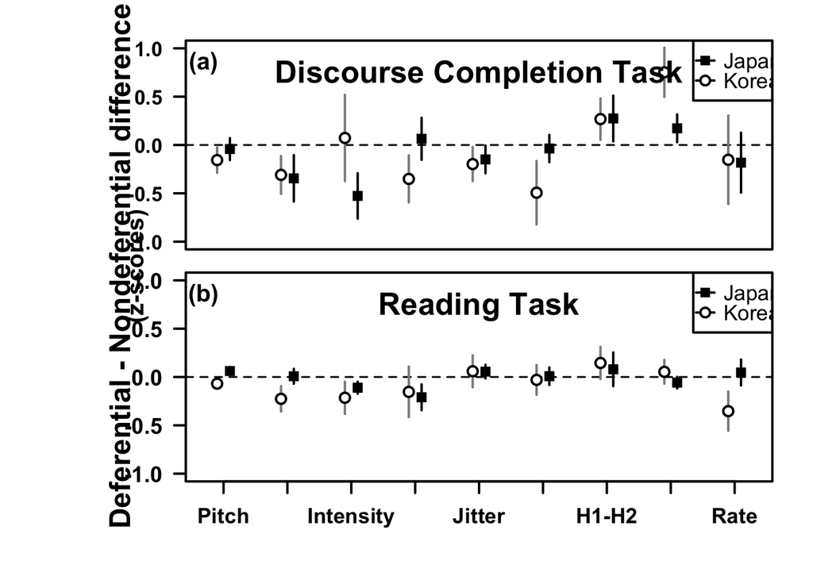

```r
quartz('', 12.5, 6)
par(mai = rep(0.1, 4), mfrow = c(2, 1),
    omi = c(0.75, 1.5, 0.25, 0.25))

# Plot 1:
plot(1, 1, type = 'n',
     xaxt = 'n', yaxt = 'n',
     xlab = '', ylab = '',
     xlim = c(0.5, length(mypreds) * 2 - 0.5),
     ylim = c(-1, 1))
abline(h = 0, lwd = 1.5, lty = 2)
axis(side = 2, at = seq(-1, 2, 0.5),
     las = 2, lwd.ticks = 2, font = 2, cex.axis = 1.05)
text(labels = 'Deferential - Nondeferential difference', x = -2.25, y = -1.25,
     font = 2, cex = 1.5, xpd = NA, srt = 90)
text(labels = '(z-scores)',
     x = -1.7, y = -1.25,
     font = 2, cex = 1.25, xpd = NA, srt = 90)

# Plot 1, data:
for (i in seq_along(mypreds)) {
  jap_ppt <- summary(get(str_c('j_ppt_', mypreds[i])))
  jap_ppt <- jap_ppt$coefficients['condition2_c', ]

  kor_ppt <- summary(get(str_c('k_ppt_', mypreds[i])))
  kor_ppt <- kor_ppt$coefficients['condition2_c', ]

    # Korean:

    segments(x0 = seq(1, 18, 2)[i] - x_fac,
             y0 = kor_ppt[1] - 1.96 * kor_ppt[2],
             y1 = kor_ppt[1] + 1.96 * kor_ppt[2],
             lwd = 2, col = 'grey55')

    points(x = seq(1, 18, 2)[i] - x_fac,
           y = kor_ppt[1], pch = 21, cex = 1.15,
           col = 'black', lwd = 2, bg = 'white')

    ## Japanese:

    segments(x0 = seq(1, 18, 2)[i] + x_fac,
             y0 = jap_ppt[1] - 1.96 * jap_ppt[2],
             y1 = jap_ppt[1] + 1.96 * jap_ppt[2],
             lwd = 2)

    points(x = seq(1, 18, 2)[i] + x_fac,
           y = jap_ppt[1], pch = 15, cex = 1.15)

    }
 legend('topright',
        legend = c('Japanese', 'Korean'),
        pch = c(15, 21), col = 'black',
        pt.bg = c('black', 'white'), lwd = 2,
        cex = 1.1, box.lwd = 2)

text(x = 0.38, y = 0.85, labels = '(a)',
     font = 2, cex = 1.25)
mtext('Discourse Completion Task',
      line = -2, xpd = NA, font = 2, cex = 1.6)
box(lwd = 2)

# Plot 2:
plot(1, 1, type = 'n', xaxt = 'n', yaxt = 'n',
     xlab = '', ylab = '',
     xlim = c(0.5, length(mypreds) * 2 - 0.5),
     ylim = c(-1, 1))
abline(h = 0, lwd = 1.5, lty = 2)
axis(side = 2, at = seq(-1, 2, 0.5),
     las = 2, lwd.ticks = 2, font = 2, cex.axis = 1.15)
# Plot 2, data:
for (i in seq_along(mypreds)) {
    jap_epr <- summary(get(str_c('j_epr_', mypreds[i])))
    jap_epr <- jap_epr$coefficients['condition2_c', ]

    kor_epr <- summary(get(str_c('k_epr_', mypreds[i])))
    kor_epr <- kor_epr$coefficients['condition2_c', ]

    # Korean:

    segments(x0 = seq(1, 19, 2)[i] - x_fac,
             y0 = kor_epr[1] - 1.96 * kor_epr[2],
             y1 = kor_epr[1] + 1.96 * kor_epr[2],
             lwd = 2, col = 'grey55')

    points(x = seq(1, 18, 2)[i] - x_fac,
           y = kor_epr[1], pch = 21, cex = 1.15,
           col = 'black', lwd = 2, bg = 'white')

    ## Japanese:

    segments(x0 = seq(1, 19, 2)[i] + x_fac,
             y0 = jap_epr[1] - 1.96 * jap_epr[2],
             y1 = jap_epr[1] + 1.96 * jap_epr[2],
             lwd = 2)

    points(x = seq(1, 18, 2)[i] + x_fac,
           y = jap_epr[1], pch = 15, cex = 1.15)

    }
mtext('Reading Task', line = -2,
      xpd = NA, font = 2, cex = 1.6)
text(x = 0.38, y = 0.85,
     labels = '(b)', font = 2, cex = 1.25)
axis(side = 1, at = seq(1, 18, 2),
     font = 2, cex.axis = 1.10,
     labels = c('Pitch', 'Pitch SD', 'Intensity',
                'Intensity SD', 'Jitter', 'Shimmer',
                'H1-H2', 'HNR', 'Rate'),
     lwd = 2, lwd.ticks = 2)
legend('topright',
       legend = c('Japanese', 'Korean'),
       pch = c(15, 21), col = 'black',
       pt.bg = c('black', 'white'), lwd = 2,
       cex = 1.1, box.lwd = 2)
box(lwd = 2)
```

```r
quartz.save('../figures/production_comparison.png',
            dpi = 300)
```

```r
quartz.save('../figures/production_comparison.tiff',
            dpi = 300)
```